[figure not shown]

# Tema 15: Diferencias en Diferencias

## **Parte 1: Análisis descriptivo de los datos**

### **Parte 1: Análisis descriptivo de los datos**

Nota: Este ejercicio está basado en el ejercicio “Activity 6: Difference in Differences Models” diseñado por el Prof. Spiro Maroulis (Disponible en: https://spiromar.github.io/teaching/paf573/IC6-diff-in-diff.html).

1. Cree un nuevo script en R, ponga a modo de comentario el título “Tema 15”, limpie el ambiente, defina el directorio, (instale si es necesario) y cargue los siguientes paquetes: tidyverse y jtools.
2. Use los siguientes comandos para cargar la base de dato “Student data 2010-2013”. Esta base de datos contiene información de 500 estudiantes en 4 años (2010, 2011, 2012 y 2013). La base de datos es similar a la utilizada en las actividades del curso donde se utilizó el simulador. En particular tiene 5 variables: (1) id: identificador único por estudiante; (2) year: variable que indica el año de la medición, notará que cada estudiante está en 4 filas de la base de datos, y cada fila contiene una combinación única id-year (al formato de este tipo de base de datos se le llama “long”); (3) currach: indica el rendimiento del estudiante en el año dado; (4) ses: indica su nivel socioeconómico; (5) treat; variable dummy que indica con el valor 1 si el estudiante pertenece al grupo de tratamiento, los estudiantes de este grupo, en el año 2013 recibieron el tratamiento (por ej. asistieron a un taller de reforzamiento escolar).

```r
# Importar datos
URL <- "https://raw.githubusercontent.com/spiromar/files/main/paf573/IC6-student-data-2010-2013.csv"
students <- read.csv( URL )
```

3. Usa el siguiente comando para mirar las primeras filas de la base de datos. ¿Qué variables son constantes para un mismo individuo? A estas variables se les llama caso-específicas, o invariantes en el tiempo (time-invariant). ¿Qué variables varían para un mismo individuo en los distintos momentos del tiempo? A estas variables se les llama variantes en el tiempo (time-variant).

```r
students
```

4. Utiliza los siguientes comandos para graficar cómo varía el promedio de rendimiento de los estudiantes en el tiempo. En base a ese gráfico, ¿Crees que el tratamiento haya tenido impacto en el rendimiento de los estudiantes?

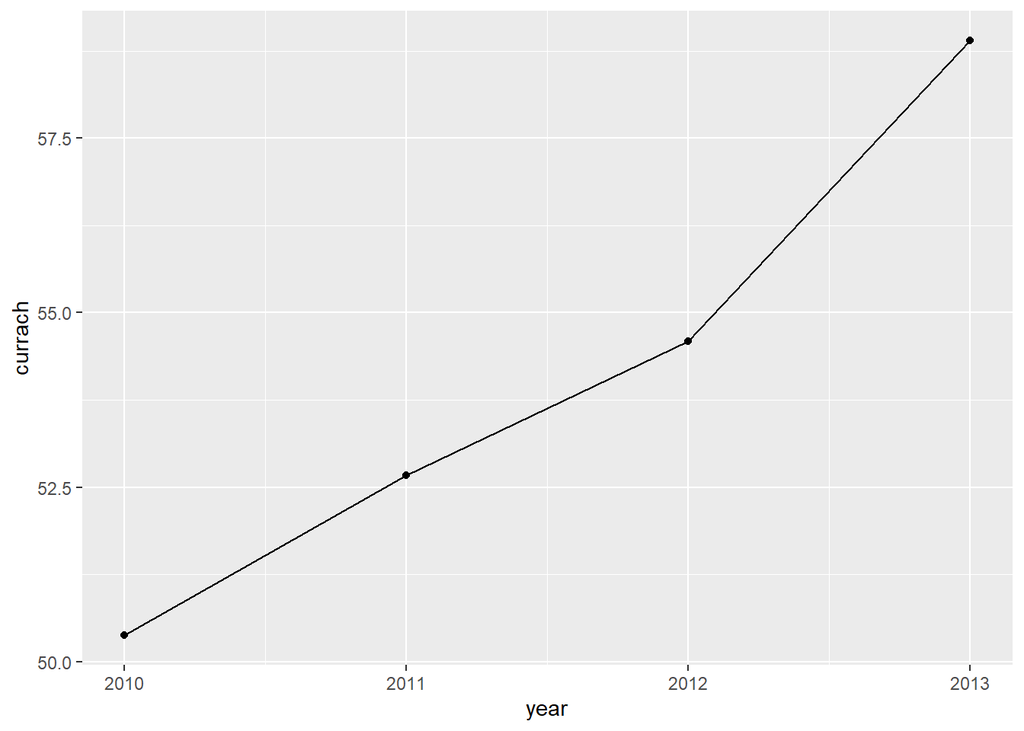

```r
ggplot(students, aes(x=year, y=currach)) +
  stat_summary(fun = "mean", geom = "point") +
  stat_summary(fun = "mean", geom = "line")
```

22. Estima una regresión para predecir el rendimiento de los estudiantes en el 2013, a partir de su grupo (tratamiento o control) y llamelo modelo 1. Repite el ejercicio controlando por nivel socioeconómico (ses) y llamelo modelo 2. ¿El ses de los estudiantes influyó en la asignación al grupo de tratamiento? ¿De qué forma? Suponiendo que no hubiese otras fuentes de endogeneidad, este segundo modelo nos dará una buena estimación del efecto del tratamiento.
6. Utilice los siguientes comandos para graficar el rendimiento de los estudiantes por año, separando por grupo de tratamiento y control. ¿Cree que el tratamiento haya tenido impacto en el rendimiento?

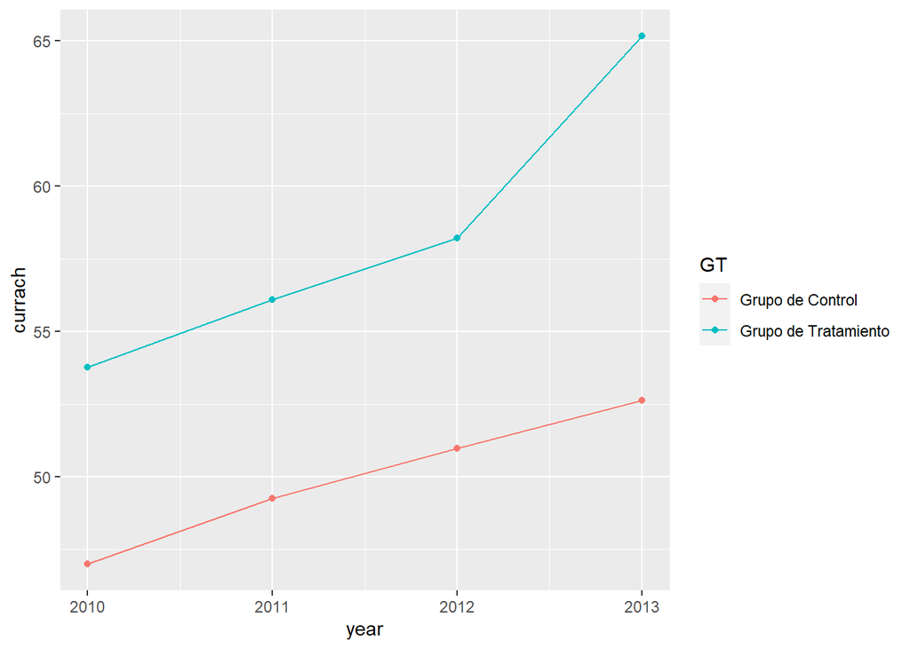

```r
students$GT<-as.factor(students$treat)
levels(students$GT)<-c("Grupo de Control", "Grupo de Tratamiento")
ggplot(students, aes(x=year, y=currach, group=treat, color=GT)) +
  stat_summary(fun = "mean", geom = "point") +
  stat_summary(fun = "mean", geom = "line")
```

## **Parte 2: Estimación del impacto del tratamiento**

### **Parte 2: Estimación del impacto del tratamiento**

Nota: Este ejercicio está basado en el ejercicio “Activity 6: Difference in Differences Models” diseñado por el Prof. Spiro Maroulis (Disponible en: https://spiromar.github.io/teaching/paf573/IC6-diff-in-diff.html).

1. Utilice los siguientes comandos para obtener el promedio de rendimiento de cada grupo, en los distintos años.

```r
Prom_grupo_año<-students %>% group_by(year, treat) %>% summarize(mAch=mean(currach))
Prom_grupo_año
```

2. Suponga ahora que usted no tiene el dato del nivel socioeconómico, y por tanto, no puede estimar el modelo 2 de la parte 1. En este contexto, podemos usar DiD para estimar el efecto del tratamiento. En particular, consideraremos el año 2012 como el dato del periodo pre-tratamiento, y 2013 como el del periodo posterior al tratamiento. Teniendo esto en cuenta, estime la diferencia en rendimiento para el grupo de tratamiento (llamela dif_GT; vea diapositiva 10 Tema15.pdf). Recuerde que en R “Prom_grupo_año[i,j]” le dará el valor de la celda ubicada en la fila i y columna j de la base de datos “Prom_grupo_año”. Repita el calculo para estimar la diferencia en rendimiento para el grupo de control (y llámela dif_GC; vea diapositiva 11 Tema15.pdf)
3. Estima el impacto del tratamiento, definido como la diferencia de rendimiento en el grupo de tratamiento menos la diferencia en el grupo de control (vea diapositiva 13 Tema15.pdf).
4. Utiliza una RLM para estimar el impacto del tratamiento al comparar los años 2012 y 2013, y siguiendo la especificación del modelo de la dispositiva 16 de Tema15.pdf. Para ello crea la variable post, donde se asigne el valor 0 a los casos del año 2012 y el valor 1 a aquellos del año 2013. Observe (1) que el impacto estimado mediante la regresión (que corresponde al beta estimado para la interacción entre el grupo de tratamiento y la variable periodo de tratamiento) coincide con el impacto estimado manualmente y (2) que el efecto de tratamiento estimado es bastante cercano a la estimación del modelo 2, controlando por nivel socioeconómico.
5. Guarde su script en la carpeta de directorio.